# Analysis of CitiBike Trip Data using R

## Exploring the structure of each dataset

```r
str(Jul_2022)
```

```
## spc_tbl_ [823,488 × 13] (S3: spec_tbl_df/tbl_df/tbl/data.frame)
##  $ ride_id           : chr [1:823488] "C60D39A2484F33FB" "FDBFB9BD7A38F66D" "B153121FD7B6B014" "7EA7A3AEAAB5F621" ...
##  $ rideable_type     : chr [1:823488] "electric_bike" "electric_bike" "electric_bike" "classic_bike" ...
##  $ started_at        : chr [1:823488] "01/07/2022 00:00" "01/07/2022 00:00" "01/07/2022 00:00" "01/07/2022 00:00" ...
##  $ ended_at          : chr [1:823488] "01/07/2022 00:07" "01/07/2022 00:07" "01/07/2022 00:09" "01/07/2022 00:11" ...
##  $ start_station_name: chr [1:823488] "Sheffield Ave & Willow St" "Sheffield Ave & Willow St" NA "Sheffield Ave & Wellington Ave" ...
##  $ start_station_id  : chr [1:823488] "TA1306000032" "TA1306000032" NA "TA1307000052" ...
##  $ end_station_name  : chr [1:823488] "Sedgwick St & Schiller St" "Sedgwick St & Schiller St" NA "Sheffield Ave & Waveland Ave" ...
##  $ end_station_id    : chr [1:823488] "TA1307000143" "TA1307000143" NA "TA1307000126" ...
##  $ start_lat         : num [1:823488] 41.9 41.9 42 41.9 41.9 ...
##  $ start_lng         : num [1:823488] -87.7 -87.7 -87.7 -87.7 -87.7 ...
##  $ end_lat           : num [1:823488] 41.9 41.9 42 41.9 42 ...
##  $ end_lng           : num [1:823488] -87.6 -87.6 -87.7 -87.7 -87.7 ...
##  $ member_casual     : chr [1:823488] "member" "casual" "casual" "casual" ...
##  - attr(*, "spec")=
##   .. cols(
##   ..   ride_id = col_character(),
##   ..   rideable_type = col_character(),
##   ..   started_at = col_character(),
##   ..   ended_at = col_character(),
##   ..   start_station_name = col_character(),
##   ..   start_station_id = col_character(),
##   ..   end_station_name = col_character(),
##   ..   end_station_id = col_character(),
##   ..   start_lat = col_double(),
##   ..   start_lng = col_double(),
##   ..   end_lat = col_double(),
##   ..   end_lng = col_double(),
##   ..   member_casual = col_character()
##   .. )
##  - attr(*, "problems")=<externalptr>
```

```r
str(Aug_2022)
```

```
## spc_tbl_ [785,932 × 13] (S3: spec_tbl_df/tbl_df/tbl/data.frame)
##  $ ride_id           : chr [1:785932] "C73448054A85D3B5" "8EFB69C0CAB8779D" "9833C3D325127E48" "CD6A225BE301AB8F" ...
##  $ rideable_type     : chr [1:785932] "electric_bike" "electric_bike" "electric_bike" "electric_bike" ...
##  $ started_at        : chr [1:785932] "01/08/2022 00:00" "01/08/2022 00:00" "01/08/2022 00:00" "01/08/2022 00:00" ...
##  $ ended_at          : chr [1:785932] "01/08/2022 00:11" "01/08/2022 00:08" "01/08/2022 00:05" "01/08/2022 00:08" ...
##  $ start_station_name: chr [1:785932] NA "Michigan Ave & Washington St" "Ashland Ave & Grace St" "Streeter Dr & Grand Ave" ...
##  $ start_station_id  : chr [1:785932] NA "13001" "13319" "13022" ...
##  $ end_station_name  : chr [1:785932] NA "Wabash Ave & 9th St" "Western Ave & Grace St" "Wabash Ave & Adams St" ...
##  $ end_station_id    : chr [1:785932] NA "TA1309000010" "431" "KA1503000015" ...
##  $ start_lat         : num [1:785932] 42 41.9 42 41.9 41.9 ...
##  $ start_lng         : num [1:785932] -87.7 -87.6 -87.7 -87.6 -87.6 ...
##  $ end_lat           : num [1:785932] 42 41.9 42 41.9 41.9 ...
##  $ end_lng           : num [1:785932] -87.7 -87.6 -87.7 -87.6 -87.7 ...
##  $ member_casual     : chr [1:785932] "casual" "member" "casual" "casual" ...
##  - attr(*, "spec")=
##   .. cols(
##   ..   ride_id = col_character(),
##   ..   rideable_type = col_character(),
##   ..   started_at = col_character(),
##   ..   ended_at = col_character(),
##   ..   start_station_name = col_character(),
##   ..   start_station_id = col_character(),
##   ..   end_station_name = col_character(),
##   ..   end_station_id = col_character(),
##   ..   start_lat = col_double(),
##   ..   start_lng = col_double(),
##   ..   end_lat = col_double(),
##   ..   end_lng = col_double(),
##   ..   member_casual = col_character()
##   .. )
##  - attr(*, "problems")=<externalptr>
```

```r
str(Sep_2022)
```

```
## spc_tbl_ [701,339 × 13] (S3: spec_tbl_df/tbl_df/tbl/data.frame)
##  $ ride_id           : chr [1:701339] "51DC98F92D41C0CD" "A4BBE90F834C0422" "5349D00EEA419440" "54B14D328D05ECA9" ...
##  $ rideable_type     : chr [1:701339] "electric_bike" "classic_bike" "electric_bike" "electric_bike" ...
##  $ started_at        : chr [1:701339] "01/09/2022 00:00" "01/09/2022 00:00" "01/09/2022 00:01" "01/09/2022 00:01" ...
##  $ ended_at          : chr [1:701339] "01/09/2022 00:18" "01/09/2022 01:07" "01/09/2022 00:05" "01/09/2022 00:06" ...
##  $ start_station_name: chr [1:701339] "Clark St & Lincoln Ave" "Lincoln Ave & Sunnyside Ave" "Ashland Ave & Division St" "Blue Island Ave & 18th St" ...
##  $ start_station_id  : chr [1:701339] "13179" "TA1307000156" "13061" "13135" ...
##  $ end_station_name  : chr [1:701339] "Lincoln Ave & Belle Plaine Ave" "Manor Ave & Leland Ave" NA NA ...
##  $ end_station_id    : chr [1:701339] "TA1309000026" "KA1504000127" NA NA ...
##  $ start_lat         : num [1:701339] 41.9 42 41.9 41.9 41.9 ...
##  $ start_lng         : num [1:701339] -87.6 -87.7 -87.7 -87.7 -87.7 ...
##  $ end_lat           : num [1:701339] 42 42 41.9 41.9 41.9 ...
##  $ end_lng           : num [1:701339] -87.7 -87.7 -87.7 -87.7 -87.7 ...
##  $ member_casual     : chr [1:701339] "casual" "member" "member" "casual" ...
##  - attr(*, "spec")=
##   .. cols(
##   ..   ride_id = col_character(),
##   ..   rideable_type = col_character(),
##   ..   started_at = col_character(),
##   ..   ended_at = col_character(),
##   ..   start_station_name = col_character(),
##   ..   start_station_id = col_character(),
##   ..   end_station_name = col_character(),
##   ..   end_station_id = col_character(),
##   ..   start_lat = col_double(),
##   ..   start_lng = col_double(),
##   ..   end_lat = col_double(),
##   ..   end_lng = col_double(),
##   ..   member_casual = col_character()
##   .. )
##  - attr(*, "problems")=<externalptr>
```

```r
str(Oct_2022)
```

```
## spc_tbl_ [558,685 × 13] (S3: spec_tbl_df/tbl_df/tbl/data.frame)
##  $ ride_id           : chr [1:558685] "DCBCCF540A0AE3CB" "8BD7CD28EB78C3F0" "D6A773C844DE6EEE" "2073591EA92F95EA" ...
##  $ rideable_type     : chr [1:558685] "electric_bike" "electric_bike" "electric_bike" "electric_bike" ...
##  $ started_at        : chr [1:558685] "01/10/2022 00:00" "01/10/2022 00:00" "01/10/2022 00:00" "01/10/2022 00:00" ...
##  $ ended_at          : chr [1:558685] "01/10/2022 00:01" "01/10/2022 00:06" "01/10/2022 00:10" "01/10/2022 00:18" ...
##  $ start_station_name: chr [1:558685] NA "Racine Ave & Congress Pkwy" NA "Sheffield Ave & Wrightwood Ave" ...
##  $ start_station_id  : chr [1:558685] NA "TA1306000025" NA "TA1309000023" ...
##  $ end_station_name  : chr [1:558685] NA "Wolcott Ave & Polk St" "Southport Ave & Roscoe St" "Franklin St & Illinois St" ...
##  $ end_station_id    : chr [1:558685] NA "TA1309000064" "13071" "RN-" ...
##  $ start_lat         : num [1:558685] 42 41.9 41.9 41.9 42 ...
##  $ start_lng         : num [1:558685] -87.8 -87.7 -87.7 -87.7 -87.7 ...
##  $ end_lat           : num [1:558685] 42 41.9 41.9 41.9 42 ...
##  $ end_lng           : num [1:558685] -87.8 -87.7 -87.7 -87.6 -87.7 ...
##  $ member_casual     : chr [1:558685] "member" "member" "member" "member" ...
##  - attr(*, "spec")=
##   .. cols(
##   ..   ride_id = col_character(),
##   ..   rideable_type = col_character(),
##   ..   started_at = col_character(),
##   ..   ended_at = col_character(),
##   ..   start_station_name = col_character(),
##   ..   start_station_id = col_character(),
##   ..   end_station_name = col_character(),
##   ..   end_station_id = col_character(),
##   ..   start_lat = col_double(),
##   ..   start_lng = col_double(),
##   ..   end_lat = col_double(),
##   ..   end_lng = col_double(),
##   ..   member_casual = col_character()
##   .. )
##  - attr(*, "problems")=<externalptr>
```

```r
str(Nov_2022)
```

```
## spc_tbl_ [337,735 × 13] (S3: spec_tbl_df/tbl_df/tbl/data.frame)
##  $ ride_id           : chr [1:337735] "45A0619030A22712" "05B1EBEBACFF6094" "5446FCEB95D32460" "AF7B05772C41BBB3" ...
##  $ rideable_type     : chr [1:337735] "electric_bike" "classic_bike" "classic_bike" "electric_bike" ...
##  $ started_at        : chr [1:337735] "01/11/2022 00:00" "01/11/2022 00:00" "01/11/2022 00:00" "01/11/2022 00:00" ...
##  $ ended_at          : chr [1:337735] "01/11/2022 00:03" "01/11/2022 00:13" "01/11/2022 00:13" "01/11/2022 00:15" ...
##  $ start_station_name: chr [1:337735] "Clark St & Montrose Ave" "Lincoln Ave & Diversey Pkwy" "Halsted St & Wrightwood Ave" "California Ave & Cortez St" ...
##  $ start_station_id  : chr [1:337735] "KA1503000022" "TA1307000064" "TA1309000061" "17660" ...
##  $ end_station_name  : chr [1:337735] NA "Clifton Ave & Armitage Ave" "Clark St & North Ave" NA ...
##  $ end_station_id    : chr [1:337735] NA "TA1307000163" "13128" NA ...
##  $ start_lat         : num [1:337735] 42 41.9 41.9 41.9 42 ...
##  $ start_lng         : num [1:337735] -87.7 -87.7 -87.6 -87.7 -87.7 ...
##  $ end_lat           : num [1:337735] 42 41.9 41.9 41.9 42 ...
##  $ end_lng           : num [1:337735] -87.7 -87.7 -87.6 -87.7 -87.7 ...
##  $ member_casual     : chr [1:337735] "casual" "casual" "casual" "casual" ...
##  - attr(*, "spec")=
##   .. cols(
##   ..   ride_id = col_character(),
##   ..   rideable_type = col_character(),
##   ..   started_at = col_character(),
##   ..   ended_at = col_character(),
##   ..   start_station_name = col_character(),
##   ..   start_station_id = col_character(),
##   ..   end_station_name = col_character(),
##   ..   end_station_id = col_character(),
##   ..   start_lat = col_double(),
##   ..   start_lng = col_double(),
##   ..   end_lat = col_double(),
##   ..   end_lng = col_double(),
##   ..   member_casual = col_character()
##   .. )
##  - attr(*, "problems")=<externalptr>
```

```r
str(Dec_2022)
```

```
## spc_tbl_ [181,806 × 13] (S3: spec_tbl_df/tbl_df/tbl/data.frame)
##  $ ride_id           : chr [1:181806] "C2728784FCDB3735" "8FE02CD119032644" "918C1979B5B339D0" "94B73A76807D9E2F" ...
##  $ rideable_type     : chr [1:181806] "electric_bike" "electric_bike" "electric_bike" "electric_bike" ...
##  $ started_at        : chr [1:181806] "01/12/2022 00:01" "01/12/2022 00:01" "01/12/2022 00:02" "01/12/2022 00:04" ...
##  $ ended_at          : chr [1:181806] "01/12/2022 00:03" "01/12/2022 00:14" "01/12/2022 00:08" "01/12/2022 00:14" ...
##  $ start_station_name: chr [1:181806] "Greenview Ave & Fullerton Ave" "Wood St & Taylor St (Temp)" NA NA ...
##  $ start_station_id  : chr [1:181806] "TA1307000001" "13285" NA NA ...
##  $ end_station_name  : chr [1:181806] "Racine Ave & Fullerton Ave (Temp)" "Orleans St & Merchandise Mart Plaza" "Federal St & Polk St" NA ...
##  $ end_station_id    : chr [1:181806] "TA1306000026" "TA1305000022" "SL-008" NA ...
##  $ start_lat         : num [1:181806] 41.9 41.9 41.9 41.9 41.9 ...
##  $ start_lng         : num [1:181806] -87.7 -87.7 -87.6 -87.6 -87.7 ...
##  $ end_lat           : num [1:181806] 41.9 41.9 41.9 41.9 41.9 ...
##  $ end_lng           : num [1:181806] -87.7 -87.6 -87.6 -87.7 -87.7 ...
##  $ member_casual     : chr [1:181806] "member" "member" "member" "member" ...
##  - attr(*, "spec")=
##   .. cols(
##   ..   ride_id = col_character(),
##   ..   rideable_type = col_character(),
##   ..   started_at = col_character(),
##   ..   ended_at = col_character(),
##   ..   start_station_name = col_character(),
##   ..   start_station_id = col_character(),
##   ..   end_station_name = col_character(),
##   ..   end_station_id = col_character(),
##   ..   start_lat = col_double(),
##   ..   start_lng = col_double(),
##   ..   end_lat = col_double(),
##   ..   end_lng = col_double(),
##   ..   member_casual = col_character()
##   .. )
##  - attr(*, "problems")=<externalptr>
```

```r
str(Jan_2023)
```

```
## spc_tbl_ [190,301 × 13] (S3: spec_tbl_df/tbl_df/tbl/data.frame)
##  $ ride_id           : chr [1:190301] "F96D5A74A3E41399" "13CB7EB698CEDB88" "BD88A2E670661CE5" "C90792D034FED968" ...
##  $ rideable_type     : chr [1:190301] "electric_bike" "classic_bike" "electric_bike" "classic_bike" ...
##  $ started_at        : chr [1:190301] "21/01/2023 20:05" "10/01/2023 15:37" "02/01/2023 07:51" "22/01/2023 10:52" ...
##  $ ended_at          : chr [1:190301] "21/01/2023 20:16" "10/01/2023 15:46" "02/01/2023 08:05" "22/01/2023 11:01" ...
##  $ start_station_name: chr [1:190301] "Lincoln Ave & Fullerton Ave" "Kimbark Ave & 53rd St" "Western Ave & Lunt Ave" "Kimbark Ave & 53rd St" ...
##  $ start_station_id  : chr [1:190301] "TA1309000058" "TA1309000037" "RP-005" "TA1309000037" ...
##  $ end_station_name  : chr [1:190301] "Hampden Ct & Diversey Ave" "Greenwood Ave & 47th St" "Valli Produce - Evanston Plaza" "Greenwood Ave & 47th St" ...
##  $ end_station_id    : chr [1:190301] "202480" "TA1308000002" "599" "TA1308000002" ...
##  $ start_lat         : num [1:190301] 41.9 41.8 42 41.8 41.8 ...
##  $ start_lng         : num [1:190301] -87.6 -87.6 -87.7 -87.6 -87.6 ...
##  $ end_lat           : num [1:190301] 41.9 41.8 42 41.8 41.8 ...
##  $ end_lng           : num [1:190301] -87.6 -87.6 -87.7 -87.6 -87.6 ...
##  $ member_casual     : chr [1:190301] "member" "member" "casual" "member" ...
##  - attr(*, "spec")=
##   .. cols(
##   ..   ride_id = col_character(),
##   ..   rideable_type = col_character(),
##   ..   started_at = col_character(),
##   ..   ended_at = col_character(),
##   ..   start_station_name = col_character(),
##   ..   start_station_id = col_character(),
##   ..   end_station_name = col_character(),
##   ..   end_station_id = col_character(),
##   ..   start_lat = col_double(),
##   ..   start_lng = col_double(),
##   ..   end_lat = col_double(),
##   ..   end_lng = col_double(),
##   ..   member_casual = col_character()
##   .. )
##  - attr(*, "problems")=<externalptr>
```

```r
str(Feb_2023)
```

```
## spc_tbl_ [190,445 × 13] (S3: spec_tbl_df/tbl_df/tbl/data.frame)
##  $ ride_id           : chr [1:190445] "4617F5134B0A2BA2" "F7CC28370FE0D243" "3D5C67AFD3CF6E87" "0D3CFCF951AD63B2" ...
##  $ rideable_type     : chr [1:190445] "electric_bike" "classic_bike" "classic_bike" "electric_bike" ...
##  $ started_at        : chr [1:190445] "01/02/2023 00:01" "01/02/2023 00:03" "01/02/2023 00:05" "01/02/2023 00:11" ...
##  $ ended_at          : chr [1:190445] "01/02/2023 00:25" "01/02/2023 00:08" "01/02/2023 00:12" "01/02/2023 00:17" ...
##  $ start_station_name: chr [1:190445] NA "University Ave & 57th St" "Broadway & Ridge Ave" NA ...
##  $ start_station_id  : chr [1:190445] NA "KA1503000071" "15578" NA ...
##  $ end_station_name  : chr [1:190445] NA "Ellis Ave & 60th St" "Broadway & Berwyn Ave" "Marine Dr & Ainslie St" ...
##  $ end_station_id    : chr [1:190445] NA "KA1503000014" "13109" "KA1504000171" ...
##  $ start_lat         : num [1:190445] 41.9 41.8 42 42 41.9 ...
##  $ start_lng         : num [1:190445] -87.7 -87.6 -87.7 -87.7 -87.7 ...
##  $ end_lat           : num [1:190445] 41.9 41.8 42 42 41.9 ...
##  $ end_lng           : num [1:190445] -87.7 -87.6 -87.7 -87.7 -87.7 ...
##  $ member_casual     : chr [1:190445] "member" "casual" "member" "member" ...
##  - attr(*, "spec")=
##   .. cols(
##   ..   ride_id = col_character(),
##   ..   rideable_type = col_character(),
##   ..   started_at = col_character(),
##   ..   ended_at = col_character(),
##   ..   start_station_name = col_character(),
##   ..   start_station_id = col_character(),
##   ..   end_station_name = col_character(),
##   ..   end_station_id = col_character(),
##   ..   start_lat = col_double(),
##   ..   start_lng = col_double(),
##   ..   end_lat = col_double(),
##   ..   end_lng = col_double(),
##   ..   member_casual = col_character()
##   .. )
##  - attr(*, "problems")=<externalptr>
```

```r
str(Mar_2023)
```

```
## spc_tbl_ [258,678 × 13] (S3: spec_tbl_df/tbl_df/tbl/data.frame)
##  $ ride_id           : chr [1:258678] "3F858645ACA7EB53" "6F13A9FC965782B1" "C15F561F543E67EA" "44563F7CDABE55B6" ...
##  $ rideable_type     : chr [1:258678] "classic_bike" "electric_bike" "electric_bike" "electric_bike" ...
##  $ started_at        : chr [1:258678] "01/03/2023 00:00" "01/03/2023 00:01" "01/03/2023 00:03" "01/03/2023 00:04" ...
##  $ ended_at          : chr [1:258678] "01/03/2023 00:22" "01/03/2023 00:04" "01/03/2023 00:07" "01/03/2023 00:07" ...
##  $ start_station_name: chr [1:258678] "Racine Ave & Congress Pkwy" NA "Clark St & Lunt Ave" "Public Rack - Prairie Ave & 47th St" ...
##  $ start_station_id  : chr [1:258678] "TA1306000025" NA "KA1504000162" "814" ...
##  $ end_station_name  : chr [1:258678] "Wabash Ave & Grand Ave" "Kedzie Ave & George St" NA "Cottage Grove Ave & 47th St" ...
##  $ end_station_id    : chr [1:258678] "TA1307000117" "436" NA "TA1309000053" ...
##  $ start_lat         : num [1:258678] 41.9 41.9 42 41.8 41.9 ...
##  $ start_lng         : num [1:258678] -87.7 -87.7 -87.7 -87.6 -87.7 ...
##  $ end_lat           : num [1:258678] 41.9 41.9 42 41.8 41.9 ...
##  $ end_lng           : num [1:258678] -87.6 -87.7 -87.7 -87.6 -87.7 ...
##  $ member_casual     : chr [1:258678] "member" "member" "member" "casual" ...
##  - attr(*, "spec")=
##   .. cols(
##   ..   ride_id = col_character(),
##   ..   rideable_type = col_character(),
##   ..   started_at = col_character(),
##   ..   ended_at = col_character(),
##   ..   start_station_name = col_character(),
##   ..   start_station_id = col_character(),
##   ..   end_station_name = col_character(),
##   ..   end_station_id = col_character(),
##   ..   start_lat = col_double(),
##   ..   start_lng = col_double(),
##   ..   end_lat = col_double(),
##   ..   end_lng = col_double(),
##   ..   member_casual = col_character()
##   .. )
##  - attr(*, "problems")=<externalptr>
```

```r
str(Apr_2023)
```

```
## spc_tbl_ [426,590 × 13] (S3: spec_tbl_df/tbl_df/tbl/data.frame)
##  $ ride_id           : chr [1:426590] "563BB19A89F51F15" "AD304476EF192169" "F4490F618609D351" "08848F48F7ACF6C3" ...
##  $ rideable_type     : chr [1:426590] "classic_bike" "classic_bike" "electric_bike" "electric_bike" ...
##  $ started_at        : chr [1:426590] "01/04/2023 00:00" "01/04/2023 00:00" "01/04/2023 00:00" "01/04/2023 00:00" ...
##  $ ended_at          : chr [1:426590] "01/04/2023 00:07" "01/04/2023 00:03" "01/04/2023 00:04" "01/04/2023 00:06" ...
##  $ start_station_name: chr [1:426590] "Wentworth Ave & 35th St" "Sheffield Ave & Wrightwood Ave" "Stave St & Armitage Ave" NA ...
##  $ start_station_id  : chr [1:426590] "KA1503000005" "TA1309000023" "13266" NA ...
##  $ end_station_name  : chr [1:426590] "Halsted St & 35th St" "Sheffield Ave & Webster Ave" NA NA ...
##  $ end_station_id    : chr [1:426590] "TA1308000043" "TA1309000033" NA NA ...
##  $ start_lat         : num [1:426590] 41.8 41.9 41.9 42 41.9 ...
##  $ start_lng         : num [1:426590] -87.6 -87.7 -87.7 -87.7 -87.6 ...
##  $ end_lat           : num [1:426590] 41.8 41.9 41.9 42 41.9 ...
##  $ end_lng           : num [1:426590] -87.6 -87.7 -87.7 -87.7 -87.7 ...
##  $ member_casual     : chr [1:426590] "casual" "member" "casual" "casual" ...
##  - attr(*, "spec")=
##   .. cols(
##   ..   ride_id = col_character(),
##   ..   rideable_type = col_character(),
##   ..   started_at = col_character(),
##   ..   ended_at = col_character(),
##   ..   start_station_name = col_character(),
##   ..   start_station_id = col_character(),
##   ..   end_station_name = col_character(),
##   ..   end_station_id = col_character(),
##   ..   start_lat = col_double(),
##   ..   start_lng = col_double(),
##   ..   end_lat = col_double(),
##   ..   end_lng = col_double(),
##   ..   member_casual = col_character()
##   .. )
##  - attr(*, "problems")=<externalptr>
```

```r
str(May_2023)
```

```
## spc_tbl_ [604,827 × 13] (S3: spec_tbl_df/tbl_df/tbl/data.frame)
##  $ ride_id           : chr [1:604827] "F0664569182AFB20" "E890C841FAF9BA38" "5802807EB4E1B2E7" "CD23D2262D4B2A34" ...
##  $ rideable_type     : chr [1:604827] "electric_bike" "classic_bike" "electric_bike" "electric_bike" ...
##  $ started_at        : chr [1:604827] "01/05/2023 00:00" "01/05/2023 00:00" "01/05/2023 00:01" "01/05/2023 00:01" ...
##  $ ended_at          : chr [1:604827] "01/05/2023 00:06" "01/05/2023 00:04" "01/05/2023 00:14" "01/05/2023 00:04" ...
##  $ start_station_name: chr [1:604827] "Burling St & Diversey Pkwy" "Wabash Ave & Wacker Pl" "Larrabee St & Kingsbury St" NA ...
##  $ start_station_id  : chr [1:604827] "TA1309000036" "TA1307000131" "TA1306000009" NA ...
##  $ end_station_name  : chr [1:604827] "Southport Ave & Belmont Ave" "Wabash Ave & Grand Ave" "Southport Ave & Wellington Ave" "Chicago Ave & Sheridan Rd" ...
##  $ end_station_id    : chr [1:604827] "13229" "TA1307000117" "TA1307000006" "E008" ...
##  $ start_lat         : num [1:604827] 41.9 41.9 41.9 42 42 ...
##  $ start_lng         : num [1:604827] -87.6 -87.6 -87.6 -87.7 -87.7 ...
##  $ end_lat           : num [1:604827] 41.9 41.9 41.9 42.1 42 ...
##  $ end_lng           : num [1:604827] -87.7 -87.6 -87.7 -87.7 -87.7 ...
##  $ member_casual     : chr [1:604827] "member" "member" "member" "member" ...
##  - attr(*, "spec")=
##   .. cols(
##   ..   ride_id = col_character(),
##   ..   rideable_type = col_character(),
##   ..   started_at = col_character(),
##   ..   ended_at = col_character(),
##   ..   start_station_name = col_character(),
##   ..   start_station_id = col_character(),
##   ..   end_station_name = col_character(),
##   ..   end_station_id = col_character(),
##   ..   start_lat = col_double(),
##   ..   start_lng = col_double(),
##   ..   end_lat = col_double(),
##   ..   end_lng = col_double(),
##   ..   member_casual = col_character()
##   .. )
##  - attr(*, "problems")=<externalptr>
```

```r
str(Jun_2023)
```

```
## spc_tbl_ [719,618 × 13] (S3: spec_tbl_df/tbl_df/tbl/data.frame)
##  $ ride_id           : chr [1:719618] "1797E27992201ECA" "ECB6F680EC5ADDB7" "76862A2B6074D143" "88AF94DE4C0970F9" ...
##  $ rideable_type     : chr [1:719618] "classic_bike" "classic_bike" "electric_bike" "electric_bike" ...
##  $ started_at        : chr [1:719618] "01/06/2023 00:00" "01/06/2023 00:00" "01/06/2023 00:00" "01/06/2023 00:00" ...
##  $ ended_at          : chr [1:719618] "01/06/2023 00:14" "01/06/2023 00:04" "01/06/2023 00:08" "01/06/2023 00:11" ...
##  $ start_station_name: chr [1:719618] "Montrose Harbor" "Chicago Ave & Sheridan Rd" "Central Park Ave & Bloomingdale Ave" NA ...
##  $ start_station_id  : chr [1:719618] "TA1308000012" "E008" "18017" NA ...
##  $ end_station_name  : chr [1:719618] "Lakefront Trail & Bryn Mawr Ave" "Sheridan Rd & Noyes St (NU)" "California Ave & Francis Pl" "Public Rack - Woodlawn Ave & 63rd St N" ...
##  $ end_station_id    : chr [1:719618] "15576" "604" "13259" "951" ...
##  $ start_lat         : num [1:719618] 42 42.1 41.9 41.8 41.9 ...
##  $ start_lng         : num [1:719618] -87.6 -87.7 -87.7 -87.6 -87.7 ...
##  $ end_lat           : num [1:719618] 42 42.1 41.9 41.8 41.9 ...
##  $ end_lng           : num [1:719618] -87.7 -87.7 -87.7 -87.6 -87.7 ...
##  $ member_casual     : chr [1:719618] "member" "member" "casual" "member" ...
##  - attr(*, "spec")=
##   .. cols(
##   ..   ride_id = col_character(),
##   ..   rideable_type = col_character(),
##   ..   started_at = col_character(),
##   ..   ended_at = col_character(),
##   ..   start_station_name = col_character(),
##   ..   start_station_id = col_character(),
##   ..   end_station_name = col_character(),
##   ..   end_station_id = col_character(),
##   ..   start_lat = col_double(),
##   ..   start_lng = col_double(),
##   ..   end_lat = col_double(),
##   ..   end_lng = col_double(),
##   ..   member_casual = col_character()
##   .. )
##  - attr(*, "problems")=<externalptr>
```

## Combining all months into one dataset

```r
all_trip = bind_rows(Jul_2022,Aug_2022,Sep_2022,Oct_2022,Nov_2022,Dec_2022,
                     Jan_2023,Feb_2023,Mar_2023,Apr_2023,May_2023,Jun_2023)
```

## Cleaning unnecessary columns

```r
all_trip = all_trip %>%
  select(-c(start_lat,start_lng,end_lat,end_lng))
```

## Inspecting the new table Column

```r
colnames(all_trip)
```

```
## [1] "ride_id"            "rideable_type"      "started_at"
## [4] "ended_at"           "start_station_name" "start_station_id"
## [7] "end_station_name"   "end_station_id"     "member_casual"
```

```r
nrow(all_trip)
```

```
## [1] 5779444
```

```r
dim(all_trip)
```

```
## [1] 5779444       9
```

```r
head(all_trip)
```

```
## # A tibble: 6 × 9
##   ride_id  rideable_type started_at ended_at start_station_name start_station_id
##   <chr>    <chr>         <chr>      <chr>    <chr>              <chr>
## 1 C60D39A… electric_bike 01/07/202… 01/07/2… Sheffield Ave & W… TA1306000032
## 2 FDBFB9B… electric_bike 01/07/202… 01/07/2… Sheffield Ave & W… TA1306000032
## 3 B153121… electric_bike 01/07/202… 01/07/2… <NA>               <NA>
## 4 7EA7A3A… classic_bike  01/07/202… 01/07/2… Sheffield Ave & W… TA1307000052
## 5 56C6CCD… classic_bike  01/07/202… 01/07/2… Southport Ave & R… 13071
## 6 AAB8184… electric_bike 01/07/202… 01/07/2… <NA>               <NA>
## # ℹ 3 more variables: end_station_name <chr>, end_station_id <chr>,
## #   member_casual <chr>
```

```r
str(all_trip)
```

```
## tibble [5,779,444 × 9] (S3: tbl_df/tbl/data.frame)
##  $ ride_id           : chr [1:5779444] "C60D39A2484F33FB" "FDBFB9BD7A38F66D" "B153121FD7B6B014" "7EA7A3AEAAB5F621" ...
##  $ rideable_type     : chr [1:5779444] "electric_bike" "electric_bike" "electric_bike" "classic_bike" ...
##  $ started_at        : chr [1:5779444] "01/07/2022 00:00" "01/07/2022 00:00" "01/07/2022 00:00" "01/07/2022 00:00" ...
##  $ ended_at          : chr [1:5779444] "01/07/2022 00:07" "01/07/2022 00:07" "01/07/2022 00:09" "01/07/2022 00:11" ...
##  $ start_station_name: chr [1:5779444] "Sheffield Ave & Willow St" "Sheffield Ave & Willow St" NA "Sheffield Ave & Wellington Ave" ...
##  $ start_station_id  : chr [1:5779444] "TA1306000032" "TA1306000032" NA "TA1307000052" ...
##  $ end_station_name  : chr [1:5779444] "Sedgwick St & Schiller St" "Sedgwick St & Schiller St" NA "Sheffield Ave & Waveland Ave" ...
##  $ end_station_id    : chr [1:5779444] "TA1307000143" "TA1307000143" NA "TA1307000126" ...
##  $ member_casual     : chr [1:5779444] "member" "casual" "casual" "casual" ...
```

```r
summary(all_trip)
```

```
##    ride_id          rideable_type       started_at          ended_at
##  Length:5779444     Length:5779444     Length:5779444     Length:5779444
##  Class :character   Class :character   Class :character   Class :character
##  Mode  :character   Mode  :character   Mode  :character   Mode  :character
##  start_station_name start_station_id   end_station_name   end_station_id
##  Length:5779444     Length:5779444     Length:5779444     Length:5779444
##  Class :character   Class :character   Class :character   Class :character
##  Mode  :character   Mode  :character   Mode  :character   Mode  :character
##  member_casual
##  Length:5779444
##  Class :character
##  Mode  :character
```

## Dates to appropriate formats

```r
all_trip$date = as.Date(all_trip$started_at)
all_trip$month = format(as.Date(all_trip$date), "%m")
all_trip$day = format(as.Date(all_trip$date), "%d")
all_trip$year = format(as.Date(all_trip$date), "%Y")
all_trip$day_of_week = format(as.Date(all_trip$date), "%A")
```

## Calculating ride length

```r
all_trip$ride_length = difftime(all_trip$ended_at,all_trip$started_at)
```

```r
all_trip$ride_length <- as.numeric(as.character(all_trip$ride_length))
all_trip_v2 <- all_trip[!(all_trip$start_station_name == "HQ QR" | all_trip$ride_length<0),]
summary(all_trip_v2$ride_length)
```

```
##      Min.   1st Qu.    Median      Mean   3rd Qu.      Max.      NA's
##         0         0         0    205927         0 915148800    857736
```

```r
aggregate(all_trip_v2$ride_length ~ all_trip_v2$member_casual, FUN = mean)
```

```
##   all_trip_v2$member_casual all_trip_v2$ride_length
## 1                    casual               393037.61
## 2                    member                88606.47
```

```r
aggregate(all_trip_v2$ride_length ~ all_trip_v2$member_casual, FUN = median)
```

```
##   all_trip_v2$member_casual all_trip_v2$ride_length
## 1                    casual                       0
## 2                    member                       0
```

```r
aggregate(all_trip_v2$ride_length ~ all_trip_v2$member_casual, FUN = max)
```

```
##   all_trip_v2$member_casual all_trip_v2$ride_length
## 1                    casual               915148800
## 2                    member                63158400
```

```r
aggregate(all_trip_v2$ride_length ~ all_trip_v2$member_casual, FUN = min)
```

```
##   all_trip_v2$member_casual all_trip_v2$ride_length
## 1                    casual                       0
## 2                    member                       0
```

```r
aggregate(all_trip_v2$ride_length ~ all_trip_v2$member_casual + all_trip_v2$day_of_week,
          FUN = mean)
```

```
##    all_trip_v2$member_casual all_trip_v2$day_of_week all_trip_v2$ride_length
## 1                     casual                  Friday               379806.39
## 2                     member                  Friday                86046.86
## 3                     casual                  Monday               412836.12
## 4                     member                  Monday                93784.64
## 5                     casual                Saturday               418353.31
## 6                     member                Saturday                94663.31
## 7                     casual                  Sunday               378306.67
## 8                     member                  Sunday                89939.33
## 9                     casual                Thursday               387333.61
## 10                    member                Thursday                83558.22
## 11                    casual                 Tuesday               409899.56
## 12                    member                 Tuesday                90424.60
## 13                    casual               Wednesday               363325.91
## 14                    member               Wednesday                81915.79
```

```r
all_trip_v2$day_of_week = ordered(all_trip_v2$day_of_week,levels=c("Sunday","Monday","Tuesday",                                              "Wednesday","Thursday","Friday", "Saturday"))

aggregate(all_trip_v2$ride_length ~ all_trip_v2$member_casual + all_trip_v2$day_of_week,
          FUN = mean)
```

```
##    all_trip_v2$member_casual all_trip_v2$day_of_week all_trip_v2$ride_length
## 1                     casual                  Sunday               378306.67
## 2                     member                  Sunday                89939.33
## 3                     casual                  Monday               412836.12
## 4                     member                  Monday                93784.64
## 5                     casual                 Tuesday               409899.56
## 6                     member                 Tuesday                90424.60
## 7                     casual               Wednesday               363325.91
## 8                     member               Wednesday                81915.79
## 9                     casual                Thursday               387333.61
## 10                    member                Thursday                83558.22
## 11                    casual                  Friday               379806.39
## 12                    member                  Friday                86046.86
## 13                    casual                Saturday               418353.31
## 14                    member                Saturday                94663.31
```

```r
all_trip_v2 %>%
  mutate(weekday = wday(started_at, label = TRUE)) %>%
  group_by(member_casual, weekday) %>%
  summarise(number_of_rides = n(),average_duration = mean(ride_length)) %>%
  arrange(member_casual, weekday)
```

```
## # A tibble: 15 × 4
## # Groups:   member_casual [3]
##    member_casual weekday number_of_rides average_duration
##    <chr>         <ord>             <int>            <dbl>
##  1 casual        Sun              282930          378307.
##  2 casual        Mon              255144          412836.
##  3 casual        Tue              265016          409900.
##  4 casual        Wed              249950          363326.
##  5 casual        Thu              275305          387334.
##  6 casual        Fri              278444          379806.
##  7 casual        Sat              289488          418353.
##  8 member        Sun              423782           89939.
##  9 member        Mon              419233           93785.
## 10 member        Tue              432043           90425.
## 11 member        Wed              426026           81916.
## 12 member        Thu              435469           83558.
## 13 member        Fri              446748           86047.
## 14 member        Sat              440997           94663.
## 15 <NA>          <NA>             857736              NA
```

## Creating visualizations

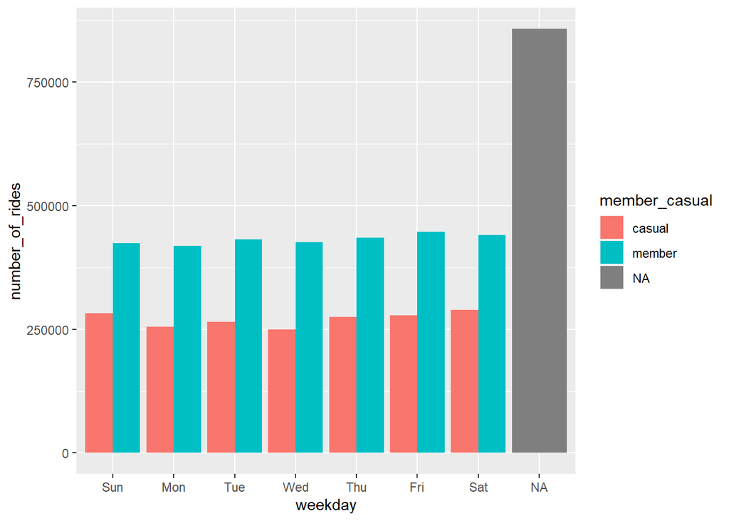

```r
all_trip_v2 %>%
  mutate(weekday = wday(started_at, label = TRUE)) %>%
  group_by(member_casual, weekday) %>%
  summarise(number_of_rides = n(),average_duration = mean(ride_length)) %>%
  arrange(member_casual, weekday) %>%
  ggplot(aes(x = weekday, y = number_of_rides, fill = member_casual)) +
  geom_col(position = "dodge")
```

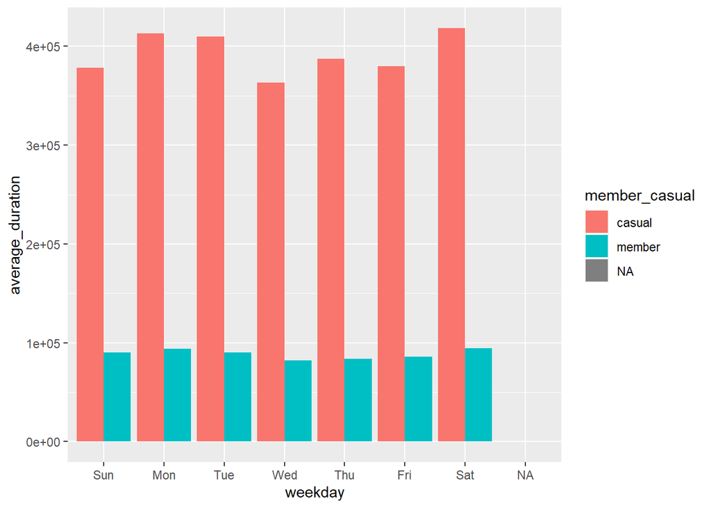

```r
all_trip_v2 %>%
  mutate(weekday = wday(started_at, label = TRUE)) %>%
  group_by(member_casual, weekday) %>%
  summarise(number_of_rides = n(),average_duration = mean(ride_length)) %>%
  arrange(member_casual, weekday) %>%
  ggplot(aes(x = weekday, y = average_duration, fill = member_casual)) +
  geom_col(position = "dodge")
```

## Exporting the summary to a CSV file

```r
counts <- aggregate(all_trip_v2$ride_length ~ all_trip_v2$member_casual +
                      all_trip_v2$day_of_week, FUN = mean)
write.csv(counts,file = "C:\\Users\\TB\\Desktop\\TAHIR\\CitiBike\\avg_ride_length.csv",row.names = FALSE)
```

## Summary of Analysis

In this analysis, we delved into Cyclistic bike-share trip data for the period from July 2022 to June 2023. Our primary objective was to understand how annual members and casual riders utilize Cyclistic bikes differently, aiming to support the design of a marketing strategy to convert casual riders into annual members.

#### Descriptive Analysis:

Descriptive statistics, including means, medians, and aggregates, were computed to understand ride lengths for different user types (members and casual riders).

#### Temporal Analysis:

We analyzed ride patterns based on days of the week to identify trends in bike usage over the week for both member types. Visualizations, including bar charts, were created to present the comparison of ride numbers and average duration across weekdays.